# Внешний Курс 1 этап

Архитектура компьютера

## Докладчик

- Володина Алиса Алексеевна
- НКАбд-01-25
- Российский университет дружбы народов им. П. Лумумбы
- 1032253521

## Цель работы

Выполнить 1 этап внешнего курса, ознакомиться с видеороликами, прикрепленными на сайте, и выполнить задания по ним.

## Задание

Выполнить 1 этап внешнего курса в stepic.

## Выполнение лабораторной работы

## 1) Вопрос: как называется этот курс? Чтобы ответить, выберите правильный ответ нажмите на зелёную кнопку ниже

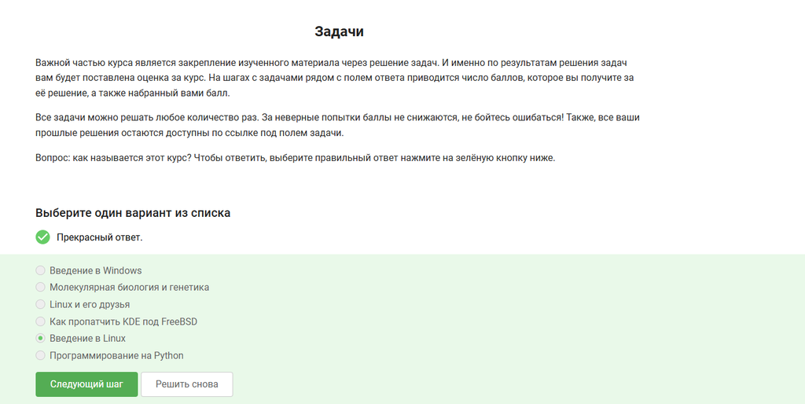

Рисунок 1: ответ на 1 вопрос

## 1

Внешний курс называется Введение в Linux

## 2) Ответить на вопросы про то, как строится курс

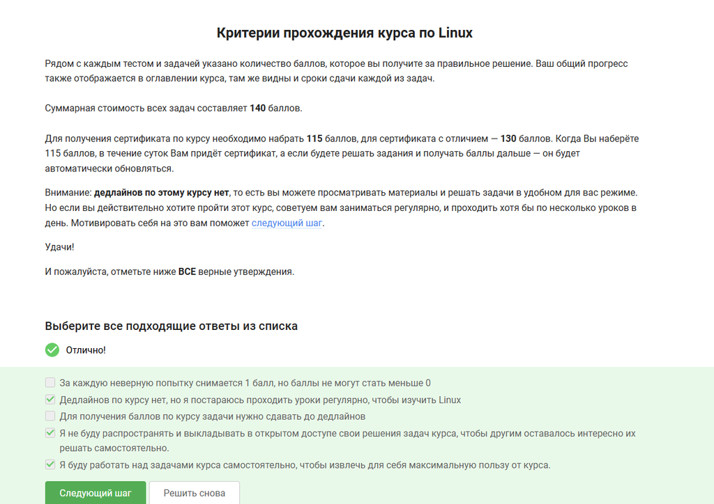

Рисунок 2: ответ на 2 вопрос

## 2

Основами курса являются такие критерии: Дедлайнов по курсу нет, но я постараюсь проходить уроки регулярно, чтобы изучить Linux, Я не буду распространять и выкладывать в открытом доступе свои решения задач курса, чтобы другим оставалось интересно их решать самостоятельно, Я буду работать над задачами курса самостоятельно, чтобы извлечь для себя максимальную пользу от курса.

## 3) Какую операционную систему вы обычно используете? В таких типах задания (с галочками/чекбоксами/checkbox) вы можете выбирать несколько вариантов ответа (от 0 до всех)!

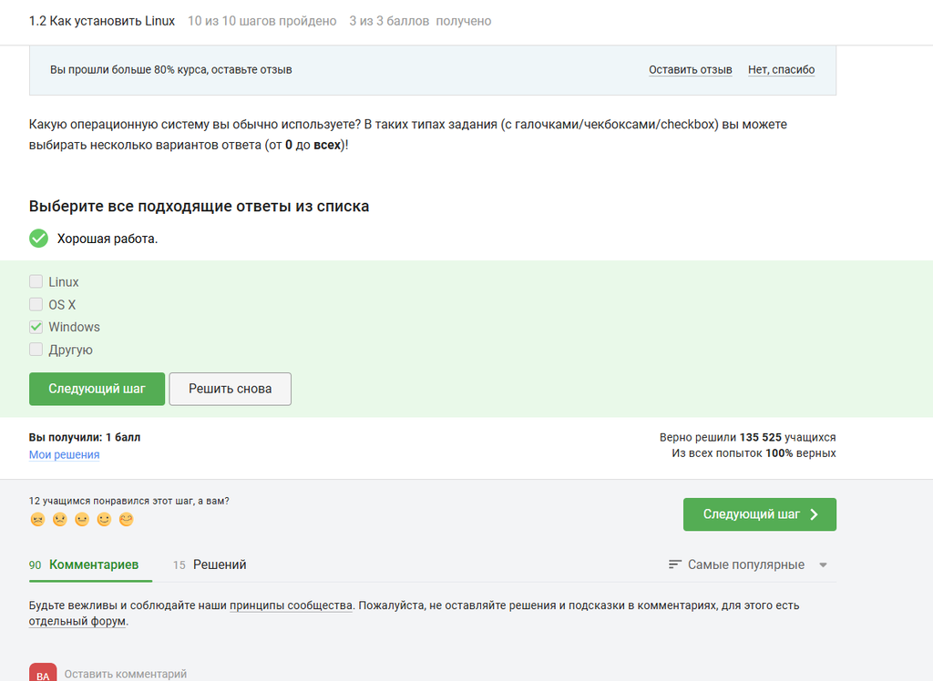

Рисунок 3: ответ на 3 вопрос

## 3

Я чаще всего использую Windows, поскольку эта операционная система установленна как основная на моем пк.

## 4) Что такое виртуальная машина? Выберите наиболее подходящий ответ! В таком типе заданий (с радиокнопками/radio button) ответ всегда ровно один!

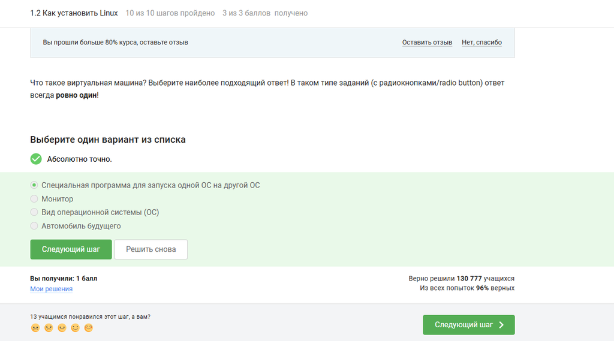

Рисунок 4: ответ на 4 вопрос

## 4

Виртуальна машина - специальная программа для запуска одной ОС на другой ОС. На виртальную машину можно ставить разнообразные операционные системы.

## 5) Смогли ли вы запустить на своем компьютере Linux?

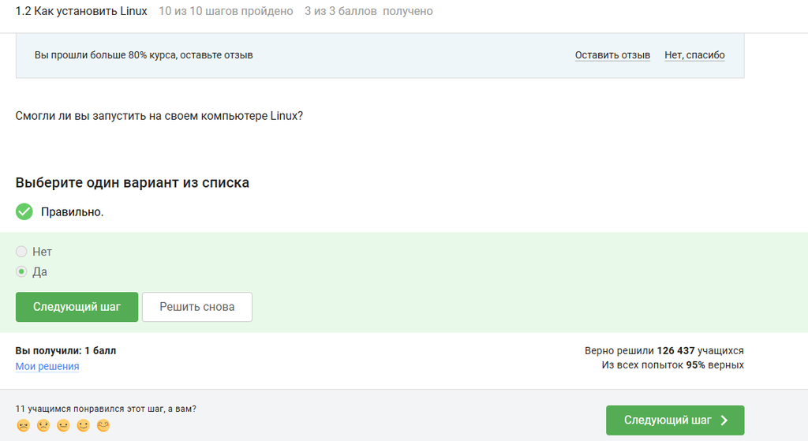

Рисунок 5: ответ на 5 вопрос

## 5

Да, на это была направлена 1 лабораторна работа предмета “архитектура компьютера”

## 6) Создайте документ в OpenOffice/LibreOffice Writer (аналог Microsoft Word) и напишите в нём шрифтом FreeMono (если такого шрифта у вас нет, то используйте Arial или Times New Roman) одну-единственную строчку: Hello, Linux!

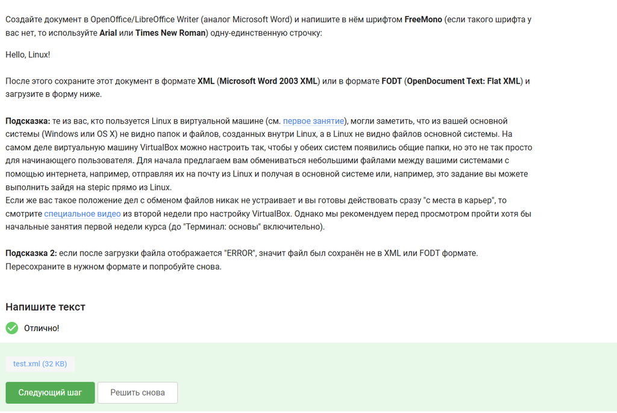

Рисунок 6: ответ на 6 вопрос

## 6

Я создала документ, вписала туда “Hello, Linux!”, сохранила в нужном формате и прикрепила в окошко дл крипления файлов

## 7) Какое расширение имеют установочные пакеты в Linux (Ubuntu)?

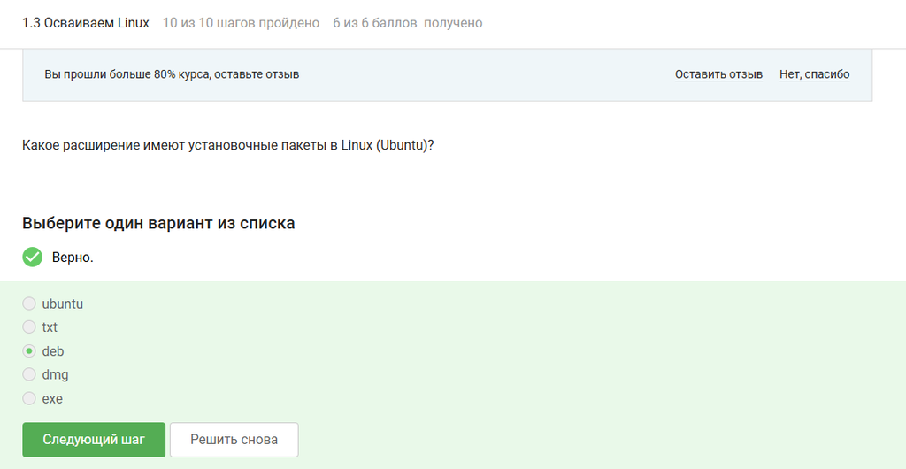

Рисунок 7: ответ на 7 вопрос

## 7

В дистрибутивах Linux, основанных на Debian, установочные пакеты имеют расширение deb. Эти файлы содержат скомпелированные программы, библиотеки и инструкции для менеджера пакетов

## 8)Запустите, откройте Help → About (или Shift+F1) и напишите ниже первую фамилию (без имени!) из вкладки Authors. Обратите внимание, что в англоязычных текстах обычно имя стоит на первом месте (first name), а фамилия на втором (last name).

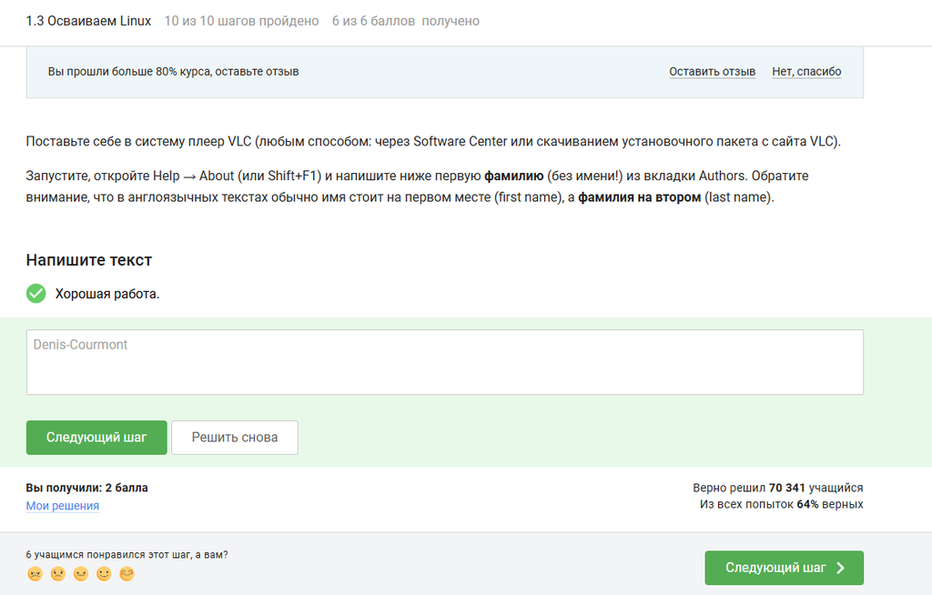

Рисунок 8: ответ на 8 вопрос

## 8

Я запустила, открыла Help → About и посмотрела, какая первая фамилия находитс в вкладке Authors. Ответ: Denis-Courmont

## 9) Для чего можно использовать приложение Update Manager?

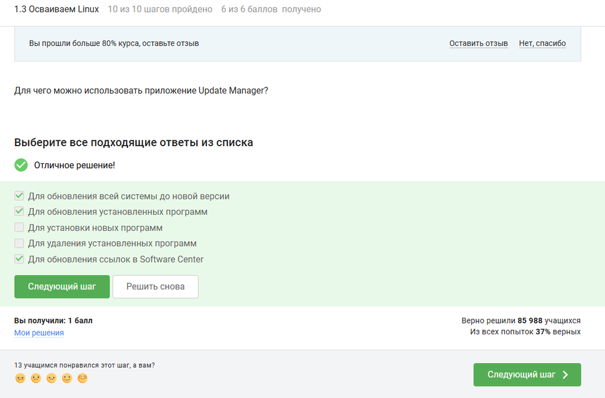

Рисунок 9: ответ на 9 вопрос

## 9

Правильными ответами являются: Для обновления всей системы до новой версии, Для обновления установленных программ, Для обновления ссылок в Software Center. Эти функции выполняет приложение Update Manager. Остальные варианты не подходят, потому что: Для установки новых программ- задача Software Center, apt install или Snap Store, Для удаления установленных программ - задача Software Center или apt remove

## 10) Выберите все синонимы для “командной строки”.

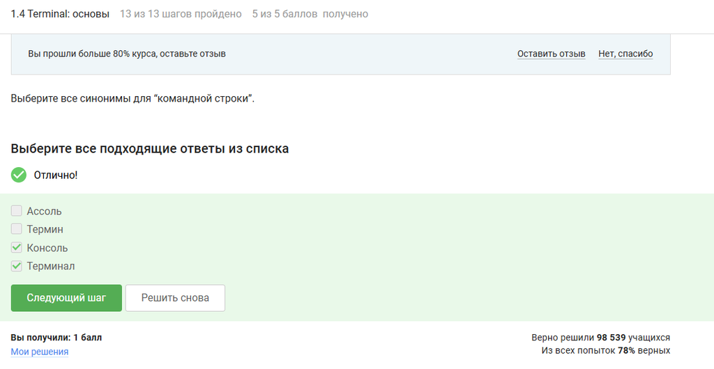

Рисунок 10: ответ на 10 вопрос

## 10

Синонимами для “командной строки” являются Консоль и Терминал, остальные варианты (Ассоль, Термин) не имеют отношения к слову “командная строка”

## 11) Какая команда напечатает в какой директории мы сейчас находимся?

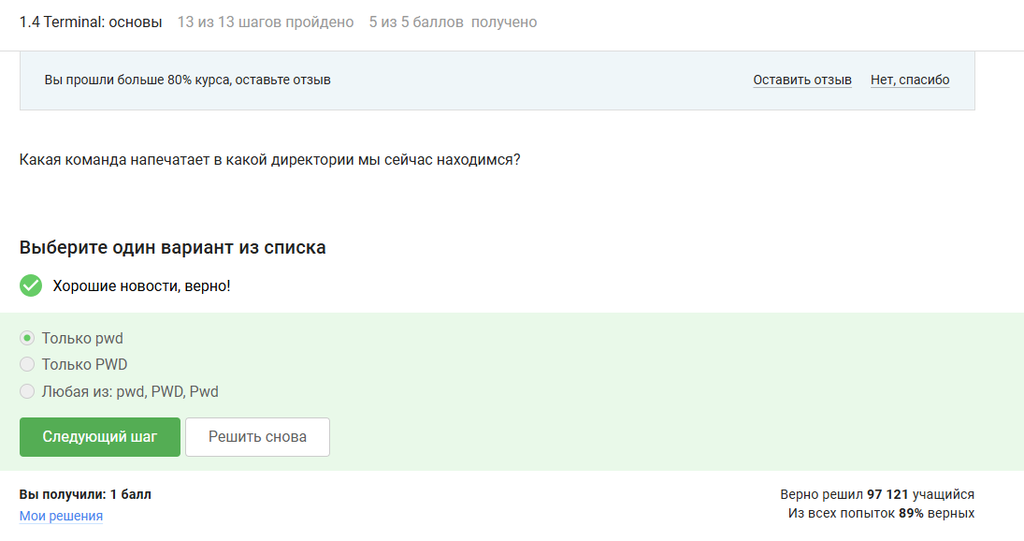

Рисунок 11: ответ на 11 вопрос

## 11

Ответ: Только pwd. Команда чувствительна к регистру: PWD — переменная, а Pwd — несуществующая команда.

## 12) Укажите, какие из следующих команд полностью эквивалентны команде ls -A –human-readable -l /some/directory

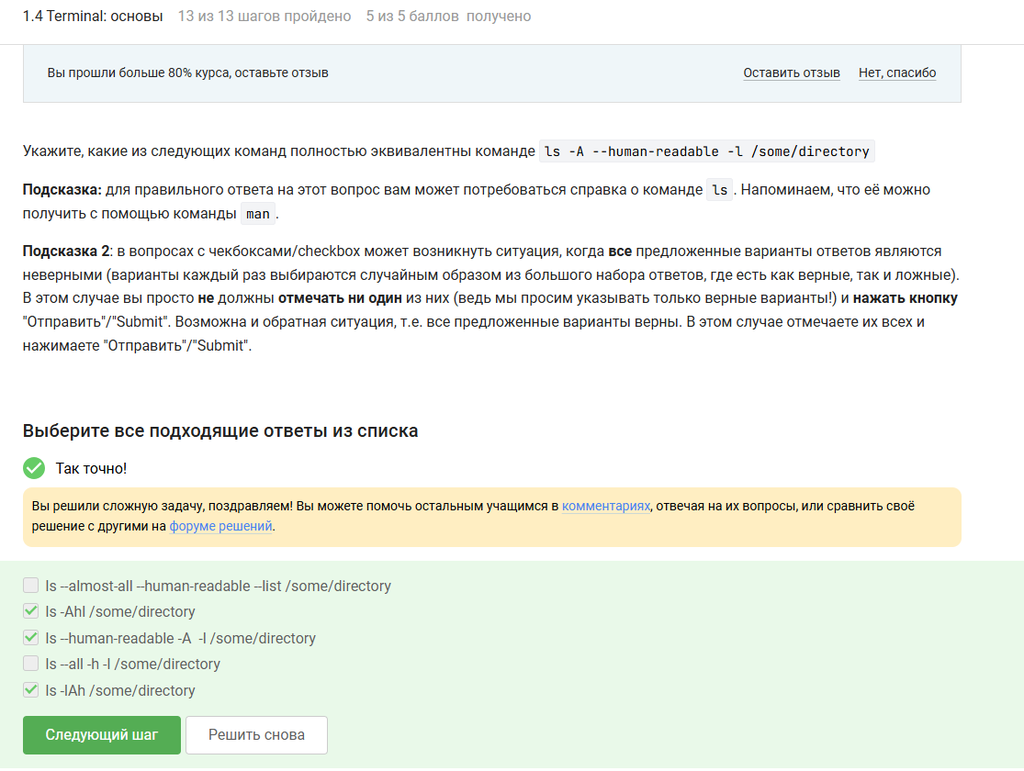

Рисунок 12: ответ на 12 вопрос

## 12

Ответ: ls -Ahl /some/directory, ls –human-readable -A -l /some/directory, ls -lAh /some/directory. Остальные варианты не подходят, потому что ls –all -h -l /some/directory — –all = -a (включает . и ..), а нужно -A (–almost-all). Не эквивалентно

## 13) Предположим, что вы находитесь в директории /home/bi/Documents, причем /home/bi — ваша домашняя директория. Какая(ие) команда выведет содержимое /home/bi/Downloads, при этом не показывая содержимое других директорий?

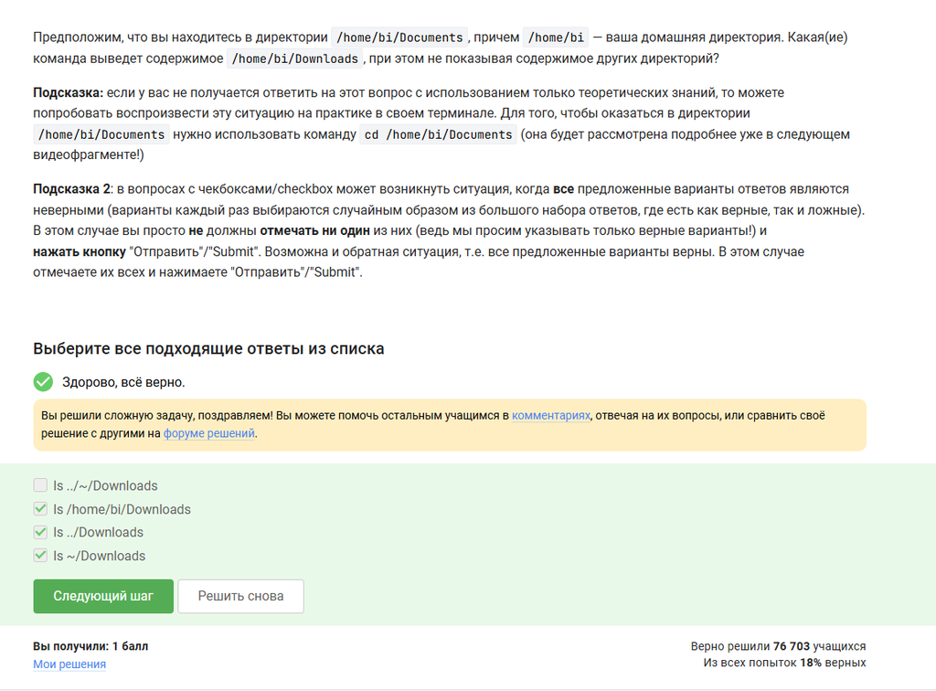

Рисунок 13: ответ на 13 вопрос

## 13

/home/bi/Downloads это абсолютный путь., ../Downloads это относительный: из /home/bi/Documents подняться на уровень выше (/home/bi/) в Downloads. ~/Downloads это ~ = домашняя директория (/home/bi). Не подходит: ls ../~/Downloads это синтаксически неверно (.. и ~ вместе не работают как путь).

## 14) Какая команда используется для удаления директорий?

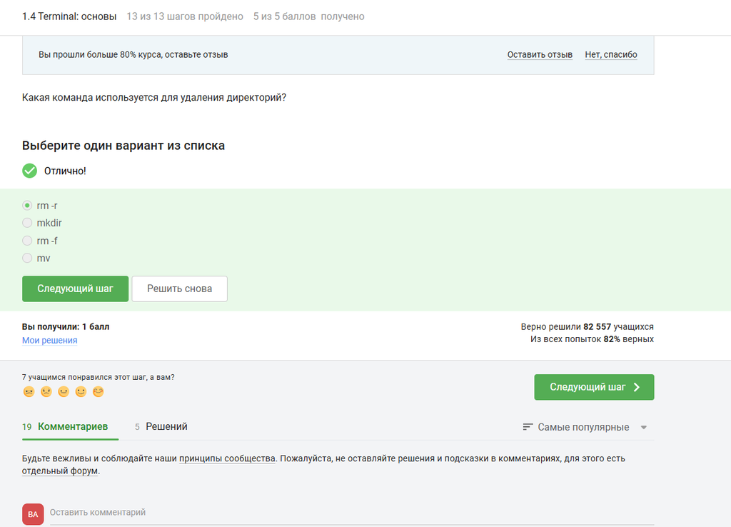

Рисунок 14: ответ на 14 вопрос

## 14

rm -r - удаляет директорию рекурсивно (вместе с содержимым), mkdir - создаёт директории, rm -f - удаляет только файлы (без рекурсии, -f — принудительно), mv - перемещает/переименовывает.

## 15) Что произойдет, если ввести в терминал команду firefox (для запуска одноименного браузера), а затем ввести туда же команду exit?

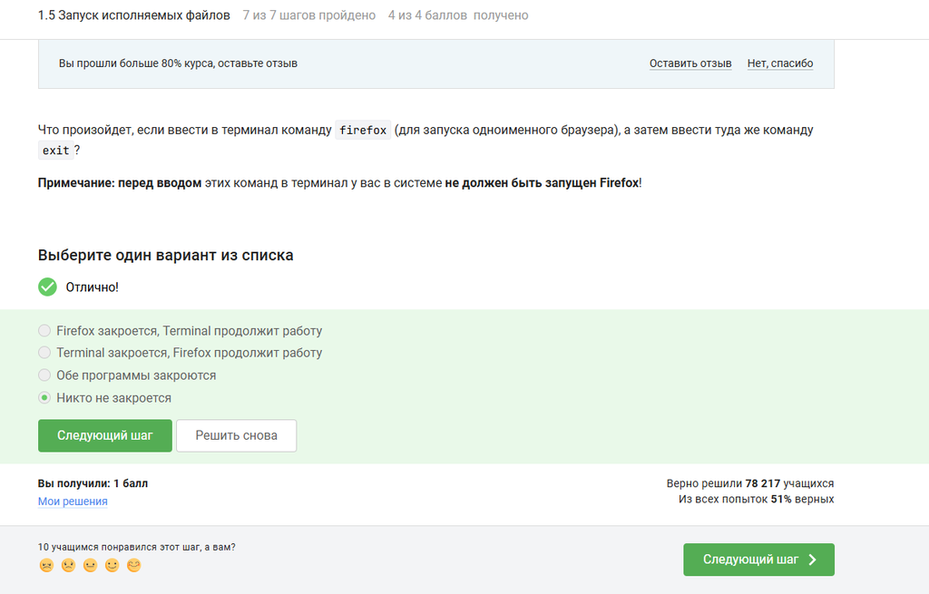

Рисунок 15: ответ на 15 вопрос

## 15

Оба процесса (Firefox и терминал) продолжают существовать, если терминал - это окно, которое не закрывается автоматически после exit

## 16) Чему эквивалентен запуск программы с &?

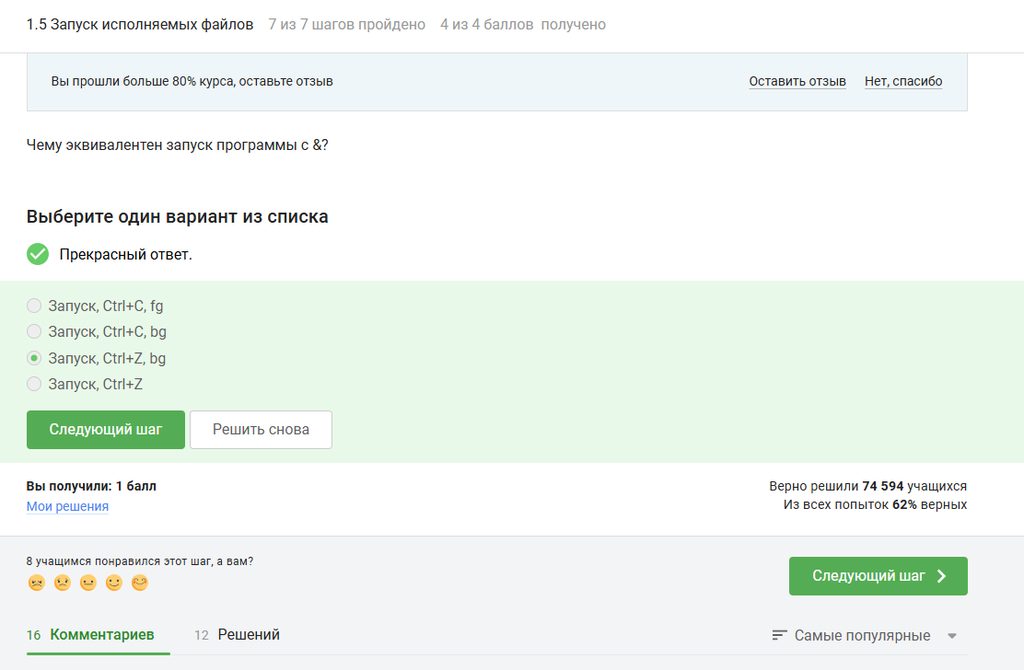

Рисунок 16: ответ на 16 вопрос

## 16

& запускает программу в фоне сразу. Вручную это делается так: Запуск программы (нажимаем Enter), останавливаем её через Ctrl+Z (приостановка), переводим в фон командой bg.

## 17) Скачайте файл с программой, сделайте его исполняемым, запустите и скопируйте то, что он выведет на экран, в форму ниже.

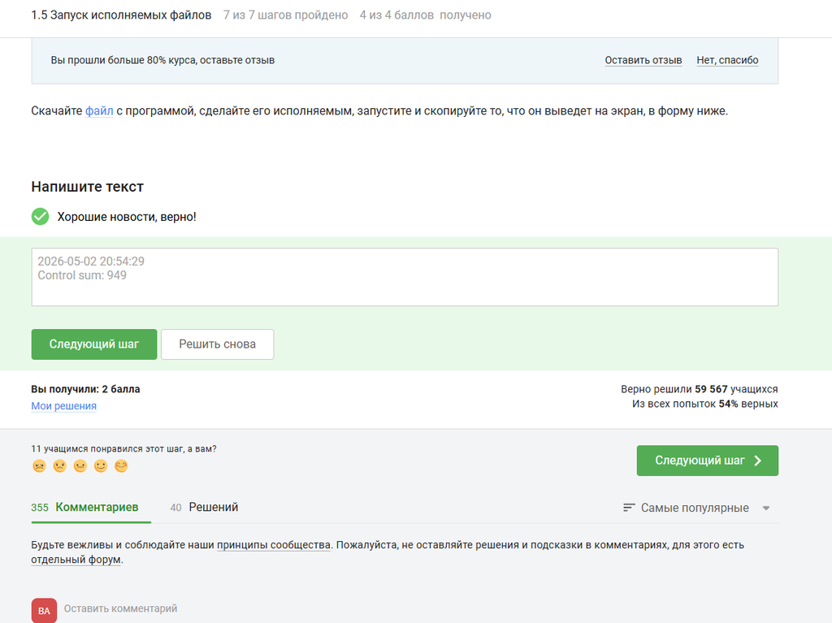

Рисунок 17: ответ на 17 вопрос

## 17

Я скачала файл с программой, сделала его исполняемым, запустила и получила такой результат: 2026-05-02 20:54:29 Control sum: 949

## 18) Куда по умолчанию выводится поток ошибок из программы, запущенной в терминале?

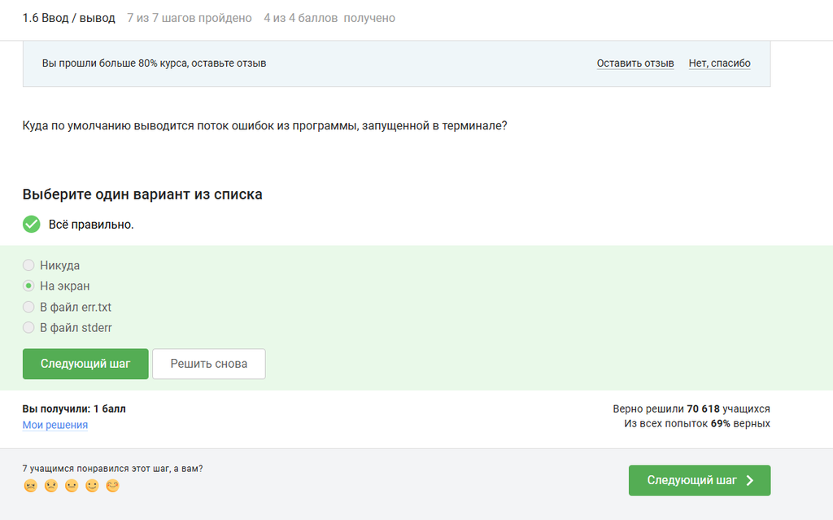

Рисунок 18: ответ на 18 вопрос

## 18

Поток ошибок (stderr) по умолчанию выводится на экран (тот же терминал, что и stdout), но не перенаправляется автоматически в файл.

## 19) Какие (какая) из команд создадут файл file.txt и запишут в него поток ошибок программы program? Считайте, что в момент запуска программы файл file.txt не существует.

[figure not shown]

Рисунок 19: ответ на 19 вопрос

## 19

Вернуе варианты: program 2> file.txt, program 2>> file.txt. Остальные варианты не подходят, потому что >> / < / << — работают с stdout или вводом, а не с stderr, program file.txt <2 — синтаксически неверно.

## 20) Куда деваются сообщения об ошибках (т.е. вывод в stderr) от тех программ, которые объединены в конвейер (pipe)?

[figure not shown]

Рисунок 20: ответ на 20 вопрос

## 20

В конвейере (pipe) перенаправляется только stdout между командами. stderr (поток ошибок) по умолчанию остаётся на экране (терминале) и не попадает в конвейер.

## 21) В каком файле на диске окажется картинка, если для её скачивания были выполнены следующие команды?

cd /home/alex/, wget -P /home/alex/Pictures -O 1.jpg http://example.com/example.jpg

[figure not shown]

Рисунок 21: ответ на 21 вопрос

## 21

Ключ -O (заглавная буква O) переопределяет выходной файл, игнорируя директорию из -P. Файл сохраняется в текущей рабочей директории (/home/alex/) с именем 1.jpg, а не в Pictures.

## 22) Какую опцию нужно указать команде wget, чтобы она не выводила никаких сообщений на экран (Resolving.., Connecting to.. и т.д.)?

[figure not shown]

Рисунок 22: ответ на 22 вопрос

## 22

-q (–quiet) - подавляет все сообщения (Resolving…, Connecting… и т.д.). -v (–verbose) - наоборот, делает вывод подробным (по умолчанию). -nv (–no-verbose) — отключает подробный вывод, но некоторые сообщения (ошибки, прогресс) могут остаться.

## 23) Пусть на некоторой web-странице есть ссылки на картинки в форматах png и jpg, а также ссылки на другие страницы сайта (обычные html файлы). Какие файлы будут скачаны на компьютер, если запустить wget -r -l 1 -A jpg и передать в качестве аргумента ссылку на эту web-страницу

[figure not shown]

Рисунок 23: ответ на 23 вопрос

## 23

-l 1 - глубина рекурсии 1 тогда wget скачивает стартовую HTML-страницу и все ссылки с неё (jpg и другие html-страницы). -A jpg - фильтр на сохранение только jpg, но HTML-файлы всё равно сначала скачиваются, чтобы wget мог прочитать ссылки. После завершения рекурсии wget удаляет HTML-файлы, не подходящие под -A, оставляя только jpg. png не скачиваются, так как их нет в -A jpg

## 24) Чем отличаются архиваторы gzip и zip?

[figure not shown]

Рисунок 24: ответ на 24 вопрос

## 24

gzip по умолчанию сжимает один файл в .gz, заменяя его архивом. При распаковке (gunzip) архив удаляется, восстанавливая исходный файл. zip по умолчанию создаёт отдельный архивный файл, исходные файлы не удаляет, и при распаковке сам архив остаётся на диске.

## 25) Какие из перечисленных программ-архиваторов могут создать архив из директории с файлами?

[figure not shown]

Рисунок 25: ответ на 25 вопрос

## 25

tar - архивирует директории и файлы в один файл (tar-архив), не сжимая. zip - архивирует + сжимает директории и файлы в один .zip-файл. gzip - сжимает только один файл, не работает с директорией напрямую (нужен tar для объединения).

## 26) Какой набор опций нужно указать программе tar, чтобы запаковать файлы в my_archive.tar.bz2?

[figure not shown]

Рисунок 26: ответ на 26 вопрос

## 26

c - создать архив (create). j - использовать сжатие bzip2 (получится .tar.bz2). f - указать имя файла архива.

## 27) Какая маска команды find НЕ найдет файл Alexey.jpeg?

[figure not shown]

Рисунок 27: ответ на 27 вопрос

## 27

Файл: Alexey.jpeg (с заглавной A). *.? - ищет расширение из одного символа (.j? нет, в .jpeg — 4 символа).* .jpg - ищет расширение .jpg, а у нас .jpeg. alexey.* - ищет имя с маленькой a, а у нас A заглавная. Остальные варианты найдут: *.* - любой файл с точкой подойдёт. Alex* - начинается на Alex Alexey.jpeg - полное совпадение

## 28) Предположим, что в файле text.txt записаны строки, показанные среди вариантов ответа. Отметьте только те из них, которые выведет на экран команда grep “world” text.txt.

[figure not shown]

Рисунок 28: ответ на 28 вопрос

## 28

Не подходят 3 варианта, они не подходят потому что The World Is Not Enough - заглавная W, без -i не найдёт, World - заглавная W, The word is not enough - word, а не world.

## 29) Cкачайте архив с произведениями Шекспира. Вам нужно сгенерировать файл, в котором будут все строчки из этих произведений, содержащие “love”, и загрузить этот файл в форму.

[figure not shown]

Рисунок 29: ответ на 29 вопрос

## 29

скачала файл и сгенерироала файл, в котором получила такой список

## Выводы

Я выполнила 1 этап внешнего курса, охнакомилась с видеороликами, представленными на сайте, и выполнила задания по ним.